# GAM Hirsutism

```r
# Clear environment
rm(list=ls())

# Load necessary packages
if(!require("mgcv")) {
  install.packages("mgcv", dependencies=TRUE)
  library(mgcv)
}
# 1. Data Import and Preparation

# Bear in mind that there may be some observations with missing values (NA)
hirs <- read.table("hirsutism.dat",header=T, sep="\t",fill=TRUE)

# Check structure and ensure that Treatment is a factor

summary(hirs)
```

```
##    Treatment          FGm0            FGm3             FGm6
##  Min.   :0.000   Min.   :14.57   Min.   : 4.381   Min.   : 1.786
##  1st Qu.:1.000   1st Qu.:16.23   1st Qu.: 9.557   1st Qu.: 7.202
##  Median :2.000   Median :17.65   Median :12.643   Median :10.286
##  Mean   :1.535   Mean   :18.57   Mean   :13.084   Mean   :10.853
##  3rd Qu.:3.000   3rd Qu.:20.17   3rd Qu.:16.219   3rd Qu.:14.204
##  Max.   :3.000   Max.   :28.36   Max.   :25.637   Max.   :23.411
##
##      FGm12           SysPres         DiaPres          weight
##  Min.   :-1.163   Min.   : 88.0   Min.   :46.00   Min.   : 41.00
##  1st Qu.: 5.093   1st Qu.:110.0   1st Qu.:65.00   1st Qu.: 57.00
##  Median : 7.524   Median :115.0   Median :70.00   Median : 64.00
##  Mean   : 8.911   Mean   :115.9   Mean   :70.04   Mean   : 68.06
##  3rd Qu.:12.101   3rd Qu.:120.0   3rd Qu.:75.00   3rd Qu.: 74.50
##  Max.   :22.759   Max.   :162.0   Max.   :95.00   Max.   :113.00
##                   NA's   :8       NA's   :8       NA's   :8
##      height
##  Min.   :1.480
##  1st Qu.:1.580
##  Median :1.610
##  Mean   :1.613
##  3rd Qu.:1.650
##  Max.   :1.800
##  NA's   :8
```

```r
hirs$Treatment <- as.factor(hirs$Treatment)
```

We have 8 observation, out of 99, that have missing record in patient baseline, but we do have the corresponding treatment result register.

We use the library ‘mice’ to impute missing values.

```r
library(mice)
imputed_data <- mice(hirs, m = 5, method = 'pmm', seed = 123)
hirs <- complete(imputed_data)
summary(is.na(hirs))
```

```
##  Treatment          FGm0            FGm3            FGm6
##  Mode :logical   Mode :logical   Mode :logical   Mode :logical
##  FALSE:99        FALSE:99        FALSE:99        FALSE:99
##    FGm12          SysPres         DiaPres          weight
##  Mode :logical   Mode :logical   Mode :logical   Mode :logical
##  FALSE:99        FALSE:99        FALSE:99        FALSE:99
##    height
##  Mode :logical
##  FALSE:99
```

```r
# 2. Exploratory Data Analysis

summary(hirs)
```

```
##  Treatment      FGm0            FGm3             FGm6            FGm12
##  0:23      Min.   :14.57   Min.   : 4.381   Min.   : 1.786   Min.   :-1.163
##  1:26      1st Qu.:16.23   1st Qu.: 9.557   1st Qu.: 7.202   1st Qu.: 5.093
##  2:24      Median :17.65   Median :12.643   Median :10.286   Median : 7.524
##  3:26      Mean   :18.57   Mean   :13.084   Mean   :10.853   Mean   : 8.911
##            3rd Qu.:20.17   3rd Qu.:16.219   3rd Qu.:14.204   3rd Qu.:12.101
##            Max.   :28.36   Max.   :25.637   Max.   :23.411   Max.   :22.759
##     SysPres         DiaPres          weight           height
##  Min.   : 88.0   Min.   :46.00   Min.   : 41.00   Min.   :1.480
##  1st Qu.:110.0   1st Qu.:65.00   1st Qu.: 58.00   1st Qu.:1.580
##  Median :118.0   Median :70.00   Median : 64.00   Median :1.610
##  Mean   :116.3   Mean   :70.24   Mean   : 68.42   Mean   :1.613
##  3rd Qu.:120.0   3rd Qu.:75.00   3rd Qu.: 74.50   3rd Qu.:1.650
##  Max.   :162.0   Max.   :95.00   Max.   :113.00   Max.   :1.800
```

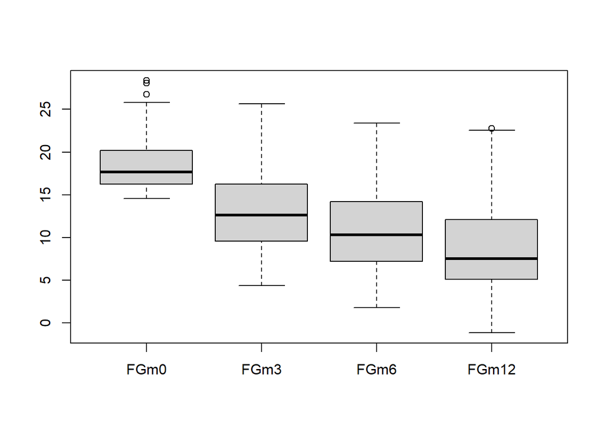

```r
attach(hirs)

boxplot(hirs[,2:5])
```

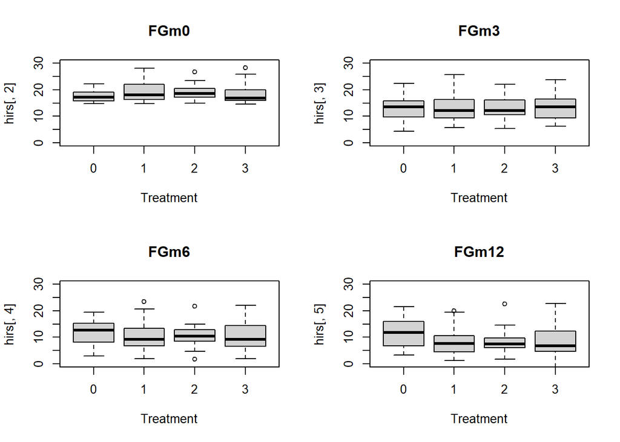

```r
par(mfrow=c(2,2))
boxplot(hirs[,2]~Treatment,ylim=c(0,30), main=names(hirs)[2], xlab="Treatment")
boxplot(hirs[,3]~Treatment,ylim=c(0,30), main=names(hirs)[3], xlab="Treatment")
boxplot(hirs[,4]~Treatment,ylim=c(0,30), main=names(hirs)[4], xlab="Treatment")
boxplot(hirs[,5]~Treatment,ylim=c(0,30), main=names(hirs)[5], xlab="Treatment")
```

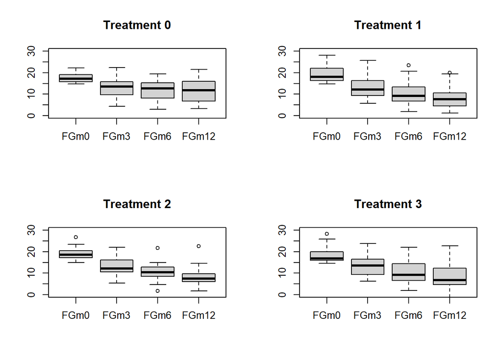

```r
par(mfrow=c(1,1))

par(mfrow=c(2,2))
boxplot(hirs[Treatment==0,2:5],ylim=c(0,30), main="Treatment 0")
boxplot(hirs[Treatment==1,2:5],ylim=c(0,30), main="Treatment 1")
boxplot(hirs[Treatment==2,2:5],ylim=c(0,30), main="Treatment 2")
boxplot(hirs[Treatment==3,2:5],ylim=c(0,30), main="Treatment 3")
```

```r
par(mfrow=c(1,1))
```

We can conclude in these four clusters that, even with contraceptive only (Treatment 0), there is a improvement of hirsutism after 12 month of treatment, although not that significant compared with other with antiandrogen.

```r
# 3. Fit Candidate GAM Models with increasing complexity.

# Model 1: A very simple model including only FGm0 and Treatment
m1 <- gam(FGm12 ~ Treatment + s(FGm0),
          data = hirs, method = "REML")

# Model 2: A more complex model model revealing the relation with patient physical status
m2 <- gam(FGm12 ~ Treatment + s(FGm0) + s(weight) + s(height),
          data = hirs, method = "REML")
# In this case, we will apply smooth function, s(), among the variables, to capture
# possible no-linear correlation between numerical feature and our target variable.

# Model 3: Include all baseline continuous vars as smooth terms and Treatment as a factor
m3 <- gam(FGm12 ~ Treatment + s(FGm0) + s(SysPres) + s(DiaPres) +
          s(weight) + s(height),data = hirs, method = "REML")

# Model 4: Allow the relationship with FGm0 to differ by Treatment (using a by-factor smooth)
m4 <- gam(FGm12 ~ Treatment + s(FGm0, by=Treatment) +
          s(SysPres) + s(DiaPres) + s(weight) + s(height),
          data = hirs, method = "REML")

# Stack all the models into a list for easy comparison.
models <- list(m1=m1, m2=m2, m3=m3, m4=m4)
```

Then let’s do a simple model comparison.

```
## ---------- m1 ----------
##
## Family: gaussian
## Link function: identity
##
## Formula:
## FGm12 ~ Treatment + s(FGm0)
##
## Parametric coefficients:
##             Estimate Std. Error t value Pr(>|t|)
## (Intercept)  12.1557     0.9685  12.551  < 2e-16 ***
## Treatment1   -4.6403     1.3392  -3.465 0.000811 ***
## Treatment2   -4.3425     1.3657  -3.180 0.002016 **
## Treatment3   -3.7064     1.3249  -2.797 0.006286 **
## ---
## Signif. codes:  0 '***' 0.001 '**' 0.01 '*' 0.05 '.' 0.1 ' ' 1
##
## Approximate significance of smooth terms:
##          edf Ref.df     F  p-value
## s(FGm0) 3.98  4.907 5.419 0.000202 ***
## ---
## Signif. codes:  0 '***' 0.001 '**' 0.01 '*' 0.05 '.' 0.1 ' ' 1
##
## R-sq.(adj) =  0.252   Deviance explained = 30.5%
## -REML = 287.99  Scale est. = 20.767    n = 99
```

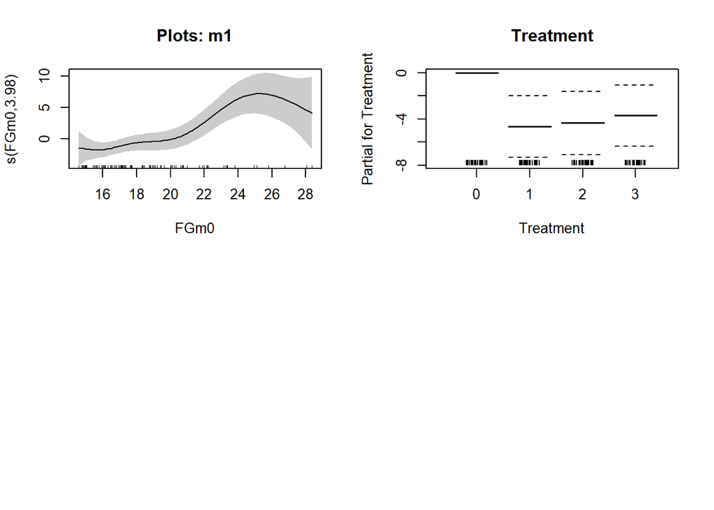

```
## gam.check for m1
```

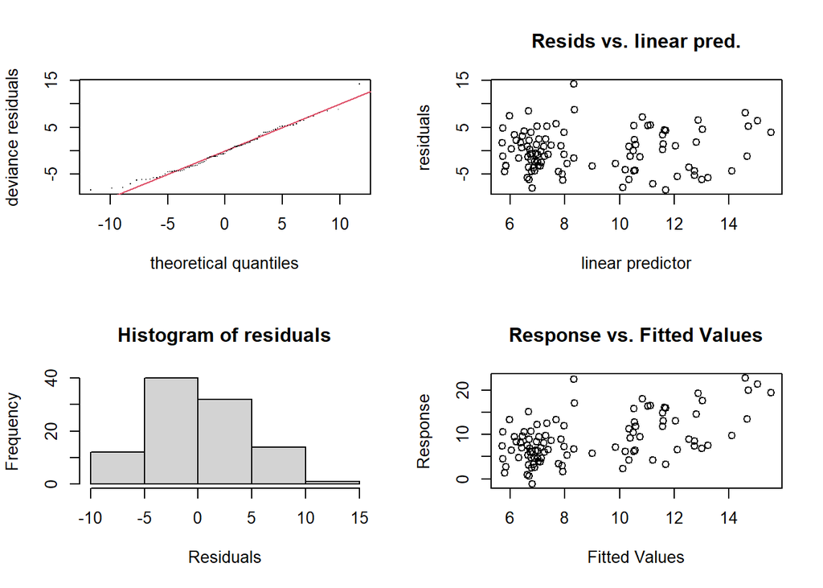

```
##
## Method: REML   Optimizer: outer newton
## full convergence after 6 iterations.
## Gradient range [-2.401611e-06,1.615454e-06]
## (score 287.9944 & scale 20.76683).
## Hessian positive definite, eigenvalue range [0.2242157,47.04745].
## Model rank =  13 / 13
##
## Basis dimension (k) checking results. Low p-value (k-index<1) may
## indicate that k is too low, especially if edf is close to k'.
##
##           k'  edf k-index p-value
## s(FGm0) 9.00 3.98    1.05    0.69
## ---------- m2 ----------
##
## Family: gaussian
## Link function: identity
##
## Formula:
## FGm12 ~ Treatment + s(FGm0) + s(weight) + s(height)
##
## Parametric coefficients:
##             Estimate Std. Error t value Pr(>|t|)
## (Intercept)  12.2510     0.9829  12.464  < 2e-16 ***
## Treatment1   -4.6265     1.3496  -3.428 0.000926 ***
## Treatment2   -4.4743     1.3905  -3.218 0.001808 **
## Treatment3   -3.9618     1.3672  -2.898 0.004740 **
## ---
## Signif. codes:  0 '***' 0.001 '**' 0.01 '*' 0.05 '.' 0.1 ' ' 1
##
## Approximate significance of smooth terms:
##             edf Ref.df     F  p-value
## s(FGm0)   4.299  5.269 5.635 0.000151 ***
## s(weight) 1.446  1.768 0.625 0.619428
## s(height) 1.001  1.001 0.776 0.381135
## ---
## Signif. codes:  0 '***' 0.001 '**' 0.01 '*' 0.05 '.' 0.1 ' ' 1
##
## R-sq.(adj) =  0.259   Deviance explained = 33.3%
## -REML = 286.96  Scale est. = 20.566    n = 99
```

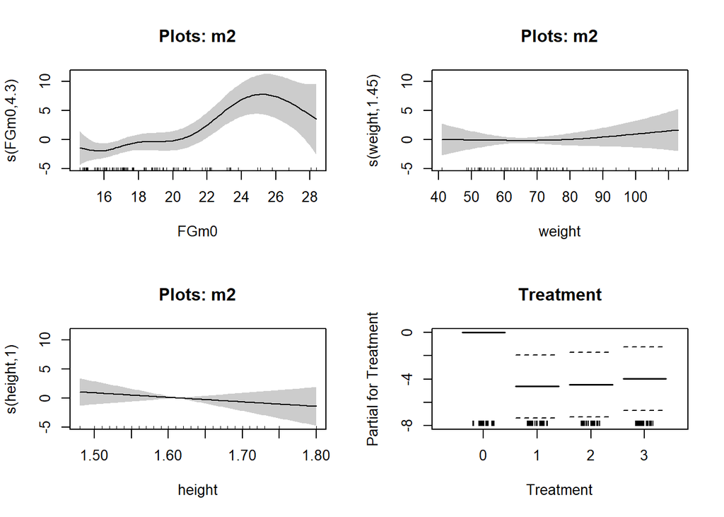

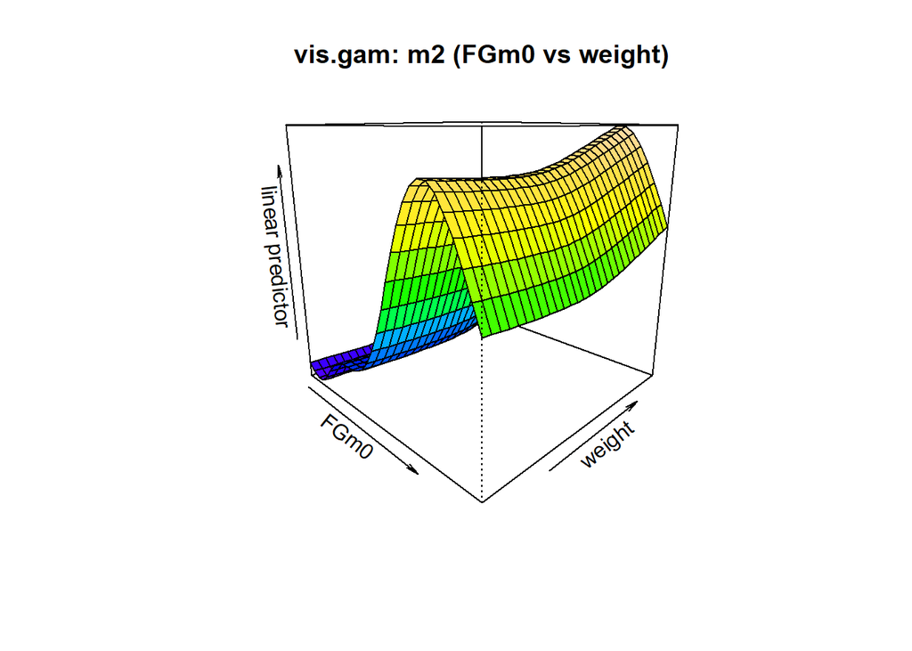

```
## gam.check for m2
```

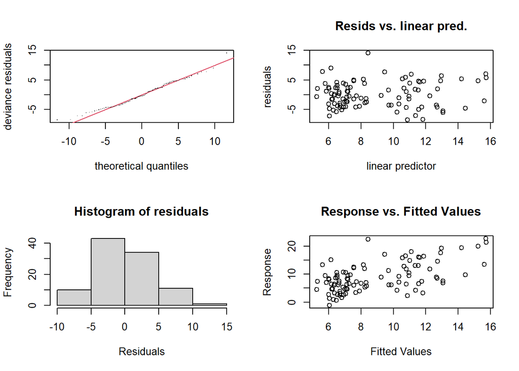

```
##
## Method: REML   Optimizer: outer newton
## full convergence after 10 iterations.
## Gradient range [-0.0001082251,0.0001728897]
## (score 286.9607 & scale 20.56589).
## Hessian positive definite, eigenvalue range [0.0001082204,46.06046].
## Model rank =  31 / 31
##
## Basis dimension (k) checking results. Low p-value (k-index<1) may
## indicate that k is too low, especially if edf is close to k'.
##
##             k'  edf k-index p-value
## s(FGm0)   9.00 4.30    1.06    0.66
## s(weight) 9.00 1.45    1.11    0.84
## s(height) 9.00 1.00    0.96    0.34
## ---------- m3 ----------
##
## Family: gaussian
## Link function: identity
##
## Formula:
## FGm12 ~ Treatment + s(FGm0) + s(SysPres) + s(DiaPres) + s(weight) +
##     s(height)
##
## Parametric coefficients:
##             Estimate Std. Error t value Pr(>|t|)
## (Intercept)  12.1551     0.9837  12.356  < 2e-16 ***
## Treatment1   -4.2957     1.3720  -3.131  0.00238 **
## Treatment2   -4.3772     1.3900  -3.149  0.00225 **
## Treatment3   -4.0169     1.3628  -2.947  0.00413 **
## ---
## Signif. codes:  0 '***' 0.001 '**' 0.01 '*' 0.05 '.' 0.1 ' ' 1
##
## Approximate significance of smooth terms:
##              edf Ref.df     F  p-value
## s(FGm0)    4.346  5.319 5.255 0.000298 ***
## s(SysPres) 1.000  1.001 2.411 0.124049
## s(DiaPres) 1.007  1.014 0.195 0.668455
## s(weight)  1.806  2.267 1.208 0.292299
## s(height)  1.000  1.000 0.722 0.398036
## ---
## Signif. codes:  0 '***' 0.001 '**' 0.01 '*' 0.05 '.' 0.1 ' ' 1
##
## R-sq.(adj) =   0.27   Deviance explained =   36%
## -REML = 284.93  Scale est. = 20.274    n = 99
```

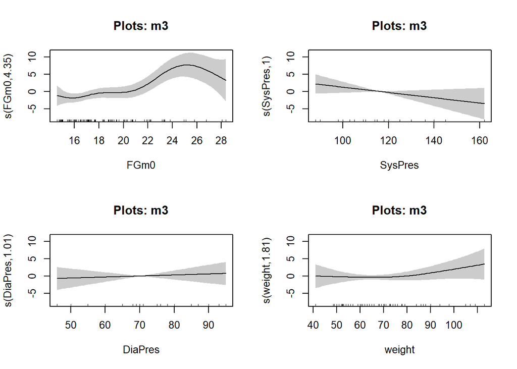

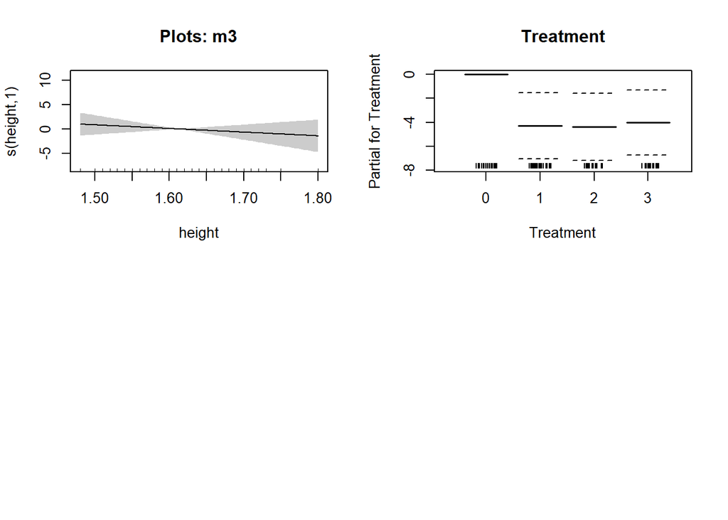

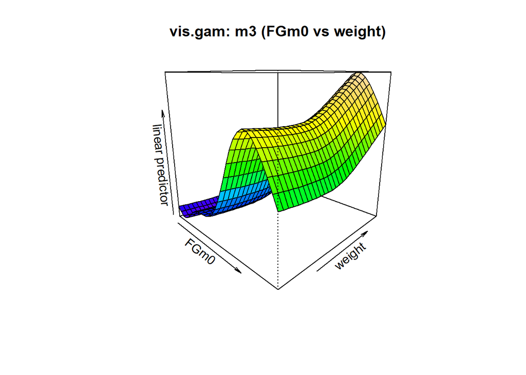

```
## gam.check for m3
```

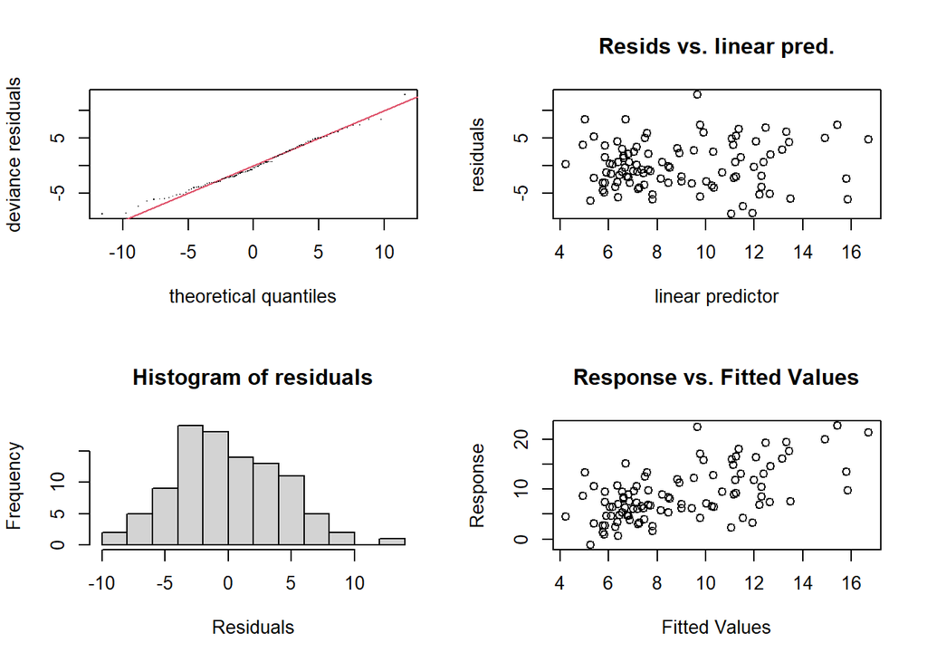

```
##
## Method: REML   Optimizer: outer newton
## full convergence after 11 iterations.
## Gradient range [-8.402997e-05,0.001241101]
## (score 284.9255 & scale 20.2738).
## Hessian positive definite, eigenvalue range [2.178024e-05,45.06505].
## Model rank =  49 / 49
##
## Basis dimension (k) checking results. Low p-value (k-index<1) may
## indicate that k is too low, especially if edf is close to k'.
##
##              k'  edf k-index p-value
## s(FGm0)    9.00 4.35    1.10    0.75
## s(SysPres) 9.00 1.00    1.08    0.74
## s(DiaPres) 9.00 1.01    1.02    0.54
## s(weight)  9.00 1.81    1.14    0.90
## s(height)  9.00 1.00    0.95    0.25
## ---------- m4 ----------
##
## Family: gaussian
## Link function: identity
##
## Formula:
## FGm12 ~ Treatment + s(FGm0, by = Treatment) + s(SysPres) + s(DiaPres) +
##     s(weight) + s(height)
##
## Parametric coefficients:
##             Estimate Std. Error t value Pr(>|t|)
## (Intercept)   11.366      1.042  10.911   <2e-16 ***
## Treatment1    -3.236      1.413  -2.290   0.0246 *
## Treatment2    -3.428      1.409  -2.434   0.0172 *
## Treatment3    -2.991      1.393  -2.147   0.0348 *
## ---
## Signif. codes:  0 '***' 0.001 '**' 0.01 '*' 0.05 '.' 0.1 ' ' 1
##
## Approximate significance of smooth terms:
##                      edf Ref.df     F  p-value
## s(FGm0):Treatment0 1.000  1.000 0.067 0.795802
## s(FGm0):Treatment1 2.603  3.244 2.434 0.057989 .
## s(FGm0):Treatment2 1.000  1.000 0.633 0.428412
## s(FGm0):Treatment3 3.184  3.924 5.667 0.000455 ***
## s(SysPres)         1.000  1.000 4.076 0.046775 *
## s(DiaPres)         1.966  2.477 0.212 0.740711
## s(weight)          2.149  2.692 1.626 0.182537
## s(height)          1.000  1.000 0.395 0.531216
## ---
## Signif. codes:  0 '***' 0.001 '**' 0.01 '*' 0.05 '.' 0.1 ' ' 1
##
## R-sq.(adj) =  0.308   Deviance explained = 42.7%
## -REML = 278.27  Scale est. = 19.214    n = 99
```

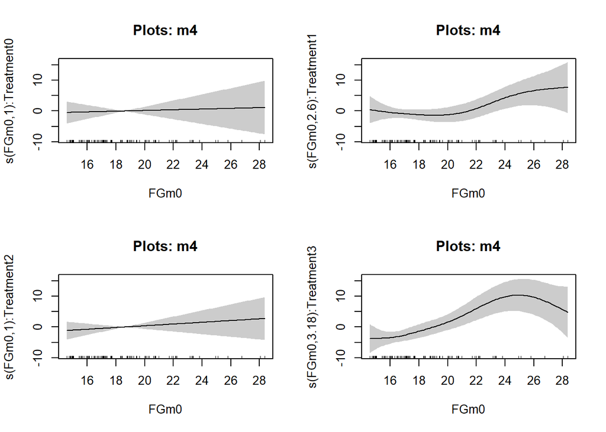

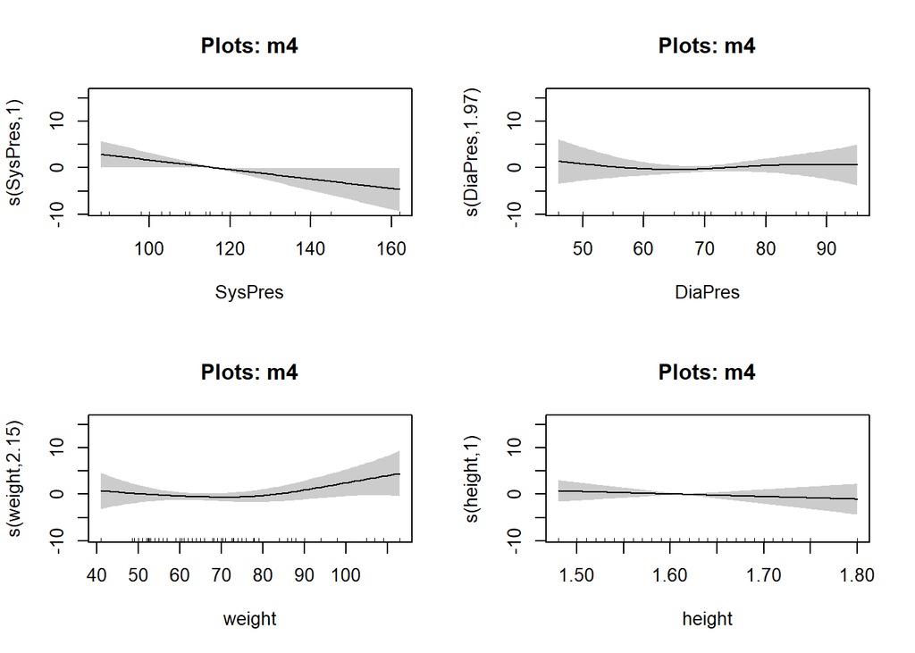

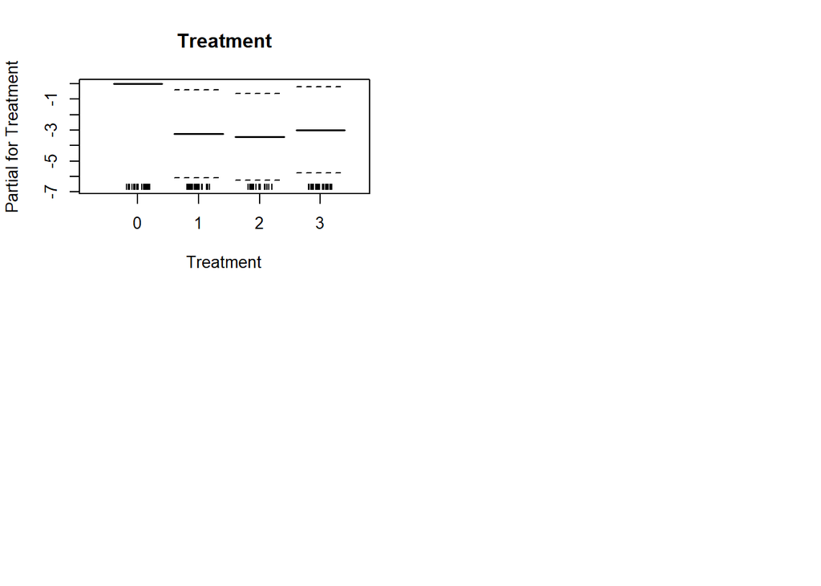

[2 more figures not shown]

```
##
## Method: REML   Optimizer: outer newton
## full convergence after 13 iterations.
## Gradient range [-3.637556e-05,0.000105553]
## (score 278.2687 & scale 19.21407).
## Hessian positive definite, eigenvalue range [2.14846e-06,43.55531].
## Model rank =  76 / 76
##
## Basis dimension (k) checking results. Low p-value (k-index<1) may
## indicate that k is too low, especially if edf is close to k'.
##
##                      k'  edf k-index p-value
## s(FGm0):Treatment0 9.00 1.00    1.04    0.63
## s(FGm0):Treatment1 9.00 2.60    1.04    0.56
## s(FGm0):Treatment2 9.00 1.00    1.04    0.58
## s(FGm0):Treatment3 9.00 3.18    1.04    0.62
## s(SysPres)         9.00 1.00    1.13    0.84
## s(DiaPres)         9.00 1.97    1.06    0.66
## s(weight)          9.00 2.15    1.11    0.80
## s(height)          9.00 1.00    1.03    0.56
```

```r
# 4. Model comparison (R-sq and Deviance explained metrics)

for (m_name in names(models)) {
  m <- models[[m_name]]

  cat("----------", m_name, "----------\n")

  # Model summary
  s <- summary(m)
  print(s)

  # Model plots
  par(mfrow=c(2,2))
  plot(m, all.terms=TRUE, shade=TRUE, main=paste("Plots:", m_name))
  par(mfrow=c(1,1))

  # Example vis.gam (only if model has at least two continuous predictors)
  if("weight" %in% names(m$model) && "FGm0" %in% names(m$model)){
    vis.gam(m, view=c("FGm0","weight"), cond=list(Treatment=levels(hirs$Treatment)[1]),
            theta=45, color="topo", main=paste("vis.gam:", m_name, "(FGm0 vs weight)"))
  }

  # gam.check
  cat("gam.check for", m_name, "\n")
  gam.check(m)
}
```

The first model has a low R-squared (0.252) and the deviance explained is also very low (30%).The next models improve the performance and the best one seems to be the fourth one, with a R-squared value of 0.308 and explained deviance of 42.7%.

```r
# Taking fourth model as baseline, let's try with different method instead of "REML"

m5 <- gam(FGm12 ~ Treatment + s(FGm0, by=Treatment) +
          s(SysPres) + s(DiaPres) + s(weight) + s(height),
          data = hirs, method = "GCV.Cp")

m6 <- gam(FGm12 ~ Treatment + s(FGm0, by=Treatment) +
          s(SysPres) + s(DiaPres) + s(weight) + s(height),
          data = hirs, method = "ML")
```

```r
# 5. Model Comparison with Anova
# Use ANOVA to compare nested models. Note:
# - Strictly, m4 is not nested in m3 (different structure due to by=Treatment),
#   but we can still get some insight. For nested comparisons, focus on models
#   that differ by terms. Alternatively, compare AIC for all models.

anova(m4, m5, m6, test="F")
```

```
## Analysis of Deviance Table
##
## Model 1: FGm12 ~ Treatment + s(FGm0, by = Treatment) + s(SysPres) + s(DiaPres) +
##     s(weight) + s(height)
## Model 2: FGm12 ~ Treatment + s(FGm0, by = Treatment) + s(SysPres) + s(DiaPres) +
##     s(weight) + s(height)
## Model 3: FGm12 ~ Treatment + s(FGm0, by = Treatment) + s(SysPres) + s(DiaPres) +
##     s(weight) + s(height)
##   Resid. Df Resid. Dev       Df Deviance      F   Pr(>F)
## 1    76.227     1558.2
## 2    73.220     1324.1   3.0073   234.14 4.4879 0.005975 **
## 3    85.411     1876.7 -12.1907  -552.66 2.6132 0.005689 **
## ---
## Signif. codes:  0 '***' 0.001 '**' 0.01 '*' 0.05 '.' 0.1 ' ' 1
```

```r
AIC(m4, m5, m6)
```

```
##          df      AIC
## m4 21.33765 596.4863
## m5 23.67489 585.0411
## m6 14.14935 600.5230
```

Comparing the Anova we can observe that the model 5 is the one with the lowest residual deviance. We can observe that the change between the fourth model and the fifth model is significant, so we can confirm that the change in the method was useful.

Regarding the AIC, the lowest one is m5 too so it re-affirms the previous observation.

```r
summary(m5)
```

```
##
## Family: gaussian
## Link function: identity
##
## Formula:
## FGm12 ~ Treatment + s(FGm0, by = Treatment) + s(SysPres) + s(DiaPres) +
##     s(weight) + s(height)
##
## Parametric coefficients:
##             Estimate Std. Error t value Pr(>|t|)
## (Intercept)   11.260      1.003  11.230   <2e-16 ***
## Treatment1    -3.407      1.372  -2.483   0.0152 *
## Treatment2    -3.324      1.353  -2.457   0.0163 *
## Treatment3    -2.821      1.351  -2.088   0.0401 *
## ---
## Signif. codes:  0 '***' 0.001 '**' 0.01 '*' 0.05 '.' 0.1 ' ' 1
##
## Approximate significance of smooth terms:
##                      edf Ref.df     F  p-value
## s(FGm0):Treatment0 1.000  1.000 0.004 0.946695
## s(FGm0):Treatment1 5.367  6.365 2.662 0.019971 *
## s(FGm0):Treatment2 1.000  1.000 0.580 0.448818
## s(FGm0):Treatment3 4.602  5.544 5.060 0.000284 ***
## s(SysPres)         1.000  1.000 5.207 0.025292 *
## s(DiaPres)         2.824  3.521 1.024 0.365644
## s(weight)          1.882  2.350 2.086 0.119409
## s(height)          1.000  1.000 0.581 0.448180
## ---
## Signif. codes:  0 '***' 0.001 '**' 0.01 '*' 0.05 '.' 0.1 ' ' 1
##
## R-sq.(adj) =  0.375   Deviance explained = 51.3%
## GCV = 22.502  Scale est. = 17.348    n = 99
```

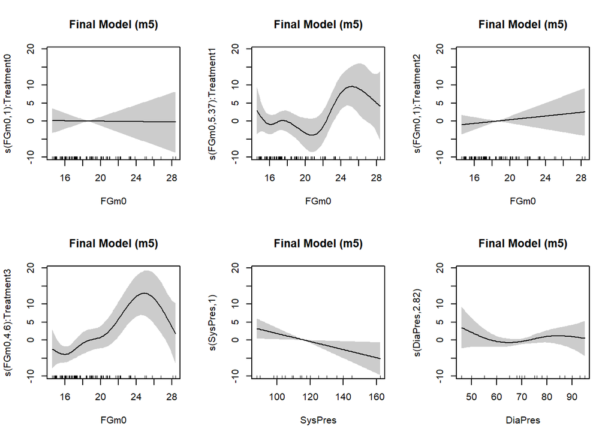

```r
# Examine partial effects more thoroughly:
par(mfrow=c(2,3))
plot(m5, all.terms=TRUE, shade=TRUE, main="Final Model (m5)")
```

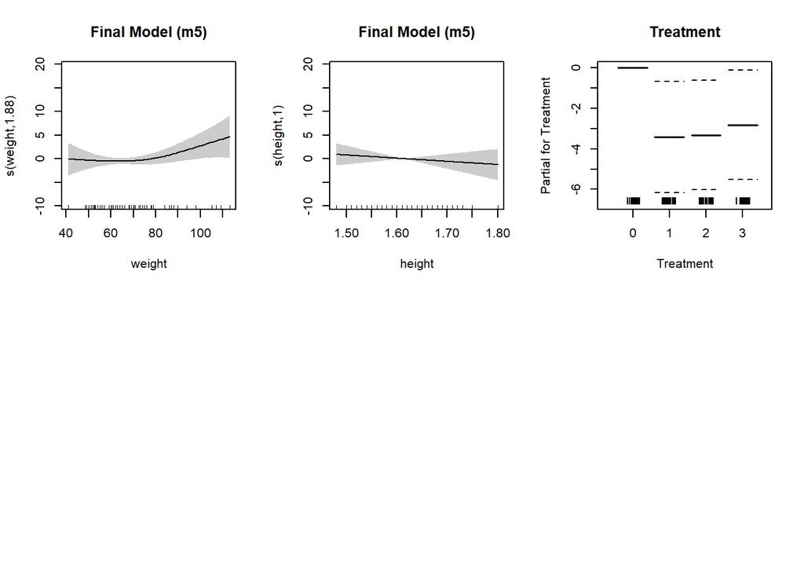

```r
par(mfrow=c(1,1))
```

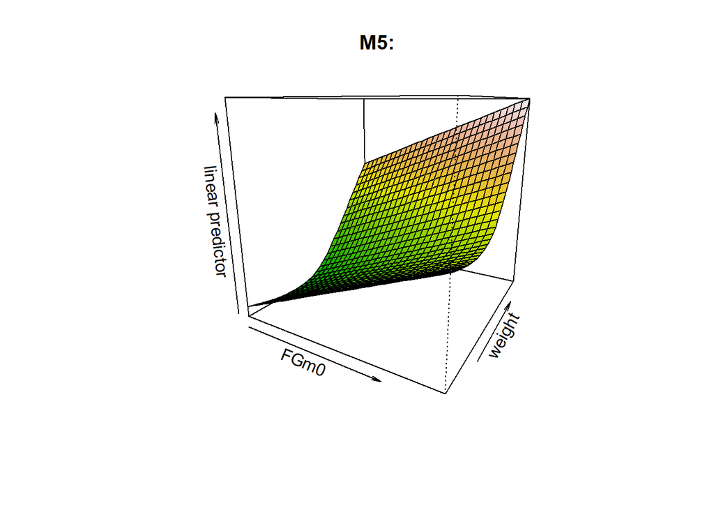

```r
# Visualize 3D surfaces for interesting pairs of predictors:
vis.gam(m5, view=c("FGm0","weight"), cond=list(Treatment="2"),
        theta=30, color="terrain", main="M5:")
```

The adjusted R-squared indicates that 0.375 of the variability in FGm12 is explained by the model. We think we may need to include more variables to improve the model.

Analysing the variables, we can see that Systolic blood pressure (s(SysPres)) shows a significant linear effect on FGm12. Diastolic blood pressure (s(DiaPres)), weight (s(weight)), and height (s(height)) were not significant predictors.

All treatment groups (1, 2, and 3) showed significant reductions in FGm12 compared to the reference group (Treatment0), with the greatest reduction in Treatment1.